# TS_HW6_Liang_Gong

```python
!pip install yfinance
!pip install pmdarima
!pip install statsmodels
!pip install arch
```

```python
import matplotlib.pyplot as plt
import numpy as np
import pandas as pd
import pmdarima as pm
import yfinance as yf

from arch import arch_model
from pmdarima.model_selection import train_test_split
from scipy.stats import chi2, jarque_bera
from sklearn.metrics import mean_absolute_percentage_error, mean_squared_error
from statsmodels.graphics.tsaplots import plot_acf, plot_pacf
from statsmodels.stats.diagnostic import acorr_ljungbox
from statsmodels.tsa.stattools import acf, adfuller
from statsmodels.graphics.gofplots import qqplot
from statsmodels.tsa.arima.model import ARIMA
from random import gauss
```

### Use the SP500 dataset discussed today and answer the questions below:

1: Select the data [2019.01.01 - 2024.04.25] and generate the time series plot. Generate ACF and PACF from both raw log return and squared log return, respectively. Make comments based on your observation.

2: Split the data (80% training and 20% testing) and fit a total of four models – ARCH(1), ARCH(2), GARCH(1,1) and GARCH(2,2). Then choose the best one (based on your opinion). Make comments based on your observation.

3: Perform McLeod-Li Test and Jarque-Bera Test (no need to do them four times!). Make comments based on your observation.

4: Make a One-step ahead rolling forecast on testing sample based on your final model. Make comments based on your observation.

# 1. Select the data [2019.01.01 - 2024.04.25] and generate the time series plot.

# Generate ACF and PACF from both raw log return and squared log return, respectively.

# Make comments based on your observation

### We begin by loading historical S&P 500 ($SPY) data from yfinance.

```python
spy = yf.Ticker("SPY")
hist = spy.history(start = "2019-01-01", end = "2024-04-26")
df = pd.DataFrame(hist, columns=['Close'])
df.head
```

```
<bound method NDFrame.head of                                 Close
Date
2019-01-02 00:00:00-05:00  227.637466
2019-01-03 00:00:00-05:00  222.205429
2019-01-04 00:00:00-05:00  229.648392
2019-01-07 00:00:00-05:00  231.459076
2019-01-08 00:00:00-05:00  233.633652
...                               ...
2024-04-19 00:00:00-04:00  490.407898
2024-04-22 00:00:00-04:00  494.924133
2024-04-23 00:00:00-04:00  500.797211
2024-04-24 00:00:00-04:00  500.559509
2024-04-25 00:00:00-04:00  498.657928

[1338 rows x 1 columns]>
```

### Let's take model log returns rather than prices. This is a convenient way to model financial assets and as such will be important to conceptualize.

### Log of Price Reture: measures the log of change in the price of the stock over a period

### This calculates daily log returns (percentage change) of the 'Close' price and ensures the first row has NaN for alignment.

```python
df['Return'] = np.pad(np.diff(np.log(df['Close'])) * 100, (1, 0), 'constant', constant_values=np.nan)
df.head()
```

| Date | Close | Return |
| --- | --- | --- |
| 2019-01-02 00:00:00-05:00 | 227.637466 | NaN |
| 2019-01-03 00:00:00-05:00 | 222.205429 | -2.415199 |
| 2019-01-04 00:00:00-05:00 | 229.648392 | 3.294710 |
| 2019-01-07 00:00:00-05:00 | 231.459076 | 0.785367 |
| 2019-01-08 00:00:00-05:00 | 233.633652 | 0.935122 |

### Time Series Plot

The time series plot shows SPDR S&P 500 ETF (SPY) close prices from 2019 to 2024. The x-axis represents dates, and the y-axis shows prices in USD. The graph highlights an overall upward trend with periods of volatility and corrections, providing insight into long-term market movements.

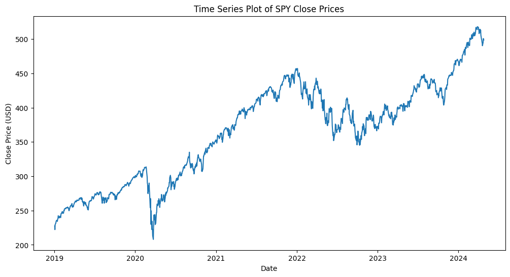

```python
plt.figure(figsize=(12, 6))
plt.plot(df.index, df['Close'])
plt.title('Time Series Plot of SPY Close Prices')
plt.xlabel('Date')
plt.ylabel('Close Price (USD)')
plt.show()
```

### Time Series Plot of Log Returns

The plot shows the log returns of SPY ETF over time, with the x-axis for dates and the y-axis for log returns. It highlights periods of high and low volatility, revealing market events and risk characteristics.

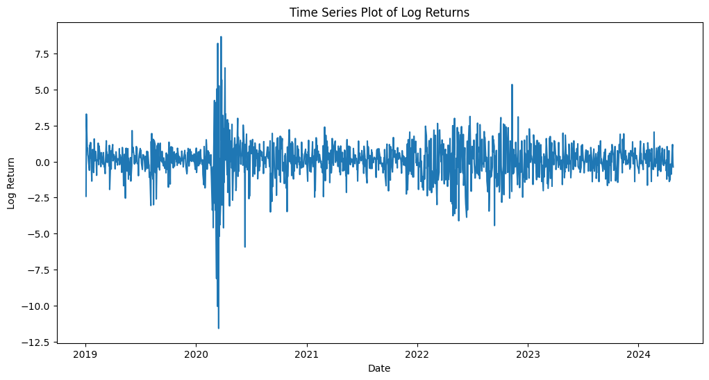

```python
plt.figure(figsize=(12, 6))
plt.plot(df['Return'])
plt.title('Time Series Plot of Log Returns')
plt.xlabel('Date')
plt.ylabel('Log Return')
plt.show()
```

### ACF and PACF for Raw Log Returns

- Plot ACF and PACF to visualize how previous returns with different lags are correlated with one another.
- The series is not independent as lags for which the ACF and PACF values are outside the blue area.
- This would imply modeling the ARCH effects.

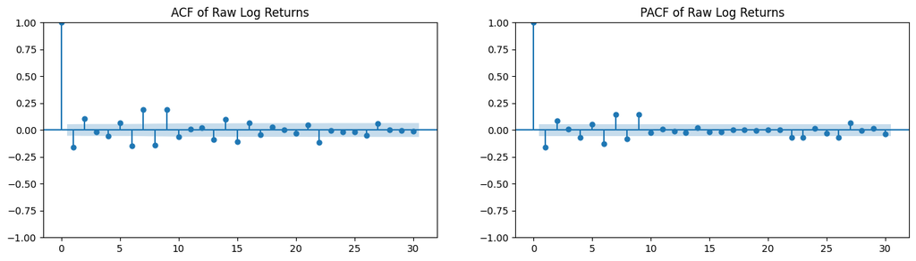

```python
fig, axes = plt.subplots(1, 2, figsize=(16, 4))

plot_acf(df['Return'].dropna(), ax=axes[0], lags=30)
axes[0].set_title('ACF of Raw Log Returns')

plot_pacf(df['Return'].dropna(), ax=axes[1], lags=30)
axes[1].set_title('PACF of Raw Log Returns')

plt.show()
```

### ACF and PACF for Squared Log Returns

- Plot ACF and PACF of squared log returns.
- There is now a pattern indicative of ARCH and GARCH effects being present.
- A slowly decaying ACF of squared log returns shows that volatility is persistent, confirming that volatility clustering exists in the raw returns
- The PACF plot suggests an autoregressive structure in squared log returns.
- In the PACF, there is not a big drop until about lag 2, which might indicate that we should have an order of P,Q up to 2.

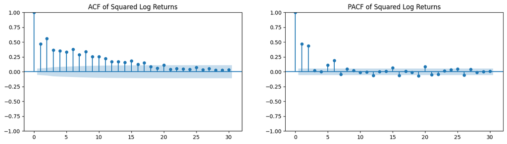

```python
df['Squared Returns'] = df['Return']**2

fig, axes = plt.subplots(1, 2, figsize=(16, 4))

plot_acf(df['Squared Returns'].dropna(), ax=axes[0], lags=30)
axes[0].set_title('ACF of Squared Log Returns')

plot_pacf(df['Squared Returns'].dropna(), ax=axes[1], lags=30)
axes[1].set_title('PACF of Squared Log Returns')

plt.show()
```

# 2. Split the data (80% training and 20% testing) and fit a total of four models – ARCH(1), ARCH(2), GARCH(1,1) and GARCH(2,2).

# Then choose the best one (based on your opinion).

# Make comments based on your observation.

```python
returns = df['Return'].iloc[1:]

# Split the data into training and testing sets (80% training, 20% testing)
train, test = train_test_split(returns, test_size=0.2)

# Fit the models
arch1 = arch_model(train, mean = "Zero", vol='Arch', p=1).fit(disp='off')
arch2 = arch_model(train, mean = "Zero", vol='Arch', p=2).fit(disp='off')
garch11 = arch_model(train, mean = "Zero", vol='Garch', p=1, q=1).fit(disp='off')
garch22 = arch_model(train, mean = "Zero", vol='Garch', p=2, q=2).fit(disp='off')
```

Here I am trying to model the volatility (σ) of df['Return'].

The variable **`garch22`** represents a **GARCH(2,2) model** fitted to the **training set of log returns**.

- `arch_model(train, mean="Zero", vol='Garch', p=2, q=2)`
  - **`vol='Garch'`**: Specifies that we are using a **GARCH model** (Generalized Autoregressive Conditional Heteroskedasticity).
  - **`mean="Zero"`**: Assumes that the **expected return is zero**, meaning we only model volatility.
  - **`p=2`**: This is the **ARCH(2) component**, meaning past squared residuals up to **lag 2** are used to predict volatility.
  - **`q=2`**: This is the **GARCH(2) component**, meaning past conditional variance (volatility) up to **lag 2** affects future volatility.

Thus, **`garch22`** is a **GARCH(2,2) model** that captures volatility clustering and persistence up to **2 lags** in both past shocks (**ARCH terms**) and past volatility (**GARCH terms**).

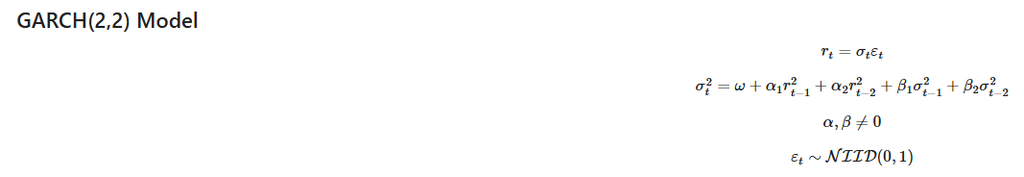

### Print the summary of the models

```python
print(arch1.summary())
print(arch2.summary())
print(garch11.summary())
print(garch22.summary())
```

```
                        Zero Mean - ARCH Model Results
==============================================================================
Dep. Variable:                 Return   R-squared:                       0.000
Mean Model:                 Zero Mean   Adj. R-squared:                  0.001
Vol Model:                       ARCH   Log-Likelihood:               -1743.75
Distribution:                  Normal   AIC:                           3491.50
Method:            Maximum Likelihood   BIC:                           3501.45
                                        No. Observations:                 1069
Date:                Fri, Feb 21 2025   Df Residuals:                     1069
Time:                        09:42:51   Df Model:                            0
                            Volatility Model
========================================================================
                 coef    std err          t      P>|t|  95.0% Conf. Int.
------------------------------------------------------------------------
omega          1.0292      0.101     10.151  3.266e-24 [  0.830,  1.228]
alpha[1]       0.4947      0.124      3.980  6.877e-05 [  0.251,  0.738]
========================================================================

Covariance estimator: robust
                        Zero Mean - ARCH Model Results
==============================================================================
Dep. Variable:                 Return   R-squared:                       0.000
Mean Model:                 Zero Mean   Adj. R-squared:                  0.001
Vol Model:                       ARCH   Log-Likelihood:               -1658.86
Distribution:                  Normal   AIC:                           3323.71
Method:            Maximum Likelihood   BIC:                           3338.64
                                        No. Observations:                 1069
Date:                Fri, Feb 21 2025   Df Residuals:                     1069
Time:                        09:42:51   Df Model:                            0
                            Volatility Model
========================================================================
                 coef    std err          t      P>|t|  95.0% Conf. Int.
------------------------------------------------------------------------
omega          0.5958  7.921e-02      7.522  5.413e-14 [  0.441,  0.751]
alpha[1]       0.3039  8.069e-02      3.766  1.656e-04 [  0.146,  0.462]
alpha[2]       0.4214  7.451e-02      5.655  1.555e-08 [  0.275,  0.567]
========================================================================

Covariance estimator: robust
                       Zero Mean - GARCH Model Results
```

[output cut: 26 more lines]

```
                                        No. Observations:                 1069
Date:                Fri, Feb 21 2025   Df Residuals:                     1069
Time:                        09:42:51   Df Model:                            0
                             Volatility Model
==========================================================================
                 coef    std err          t      P>|t|    95.0% Conf. Int.
--------------------------------------------------------------------------
omega          0.0831  2.822e-02      2.944  3.239e-03 [2.777e-02,  0.138]
alpha[1]       0.1459  5.152e-02      2.832  4.619e-03 [4.495e-02,  0.247]
alpha[2]       0.1886  6.074e-02      3.105  1.903e-03 [6.955e-02,  0.308]
beta[1]        0.1575      0.145      1.088      0.277   [ -0.126,  0.441]
beta[2]        0.4731      0.122      3.880  1.043e-04   [  0.234,  0.712]
==========================================================================

Covariance estimator: robust
```

### To correctly compare predicted volatility (variance) with the actual observed volatility, we should transform test data to represent actual volatility.

### A common approach is to use squared returns as a proxy for realized variance.

### Evaluate the models using the test set

```python
def evaluate_model(model, test_data):
    predictions = model.forecast(horizon=len(test_data))
    pred = predictions.variance.values[-1, :]  # Predicted variance (volatility^2)

    # Compute actual realized variance (squared returns)
    actual_variance = np.square(test_data)

    # Compute errors
    mse = mean_squared_error(actual_variance, pred)
    rmse = np.sqrt(mse)

    return mse, rmse

# Evaluate different models
mse_arch1, rmse_arch1 = evaluate_model(arch1, test)
mse_arch2, rmse_arch2 = evaluate_model(arch2, test)
mse_garch11, rmse_garch11 = evaluate_model(garch11, test)
mse_garch22, rmse_garch22 = evaluate_model(garch22, test)
```

### Print the evaluation metrics

```python
print(f'ARCH(1) MSE: {mse_arch1}, RMSE: {rmse_arch1}')
print(f'ARCH(2) MSE: {mse_arch2}, RMSE: {rmse_arch2}')
print(f'GARCH(1,1) MSE: {mse_garch11}, RMSE: {rmse_garch11}')
print(f'GARCH(2,2) MSE: {mse_garch22}, RMSE: {rmse_garch22}')
```

```
ARCH(1) MSE: 2.8191867554040977, RMSE: 1.6790434048600702
ARCH(2) MSE: 3.1899715016901316, RMSE: 1.786049131936222
GARCH(1,1) MSE: 3.719860979446356, RMSE: 1.9286941124622008
GARCH(2,2) MSE: 3.3383626812105023, RMSE: 1.8271186828475325
```

### **ARCH(1) Model: Best Fit for SPY ETF Returns**

#### **Evaluation Metrics Comparison**

The ARCH(1) model demonstrates the best predictive accuracy based on Mean Squared Error (MSE) and Root Mean Squared Error (RMSE):

- **MSE (2.82)**: Lowest among all models, indicating the best fit.
- **RMSE (1.68)**: Smallest error spread, confirming superior predictive performance.

#### **Model Complexity and Fit**

- **ARCH(1)**: A simple model with one lag of squared residuals, reducing the risk of overfitting while effectively capturing volatility.
- **ARCH(2) & GARCH models**: Though more complex, they do not improve predictive accuracy, as seen in higher MSE and RMSE values.

#### **Conclusion**

For SPY ETF returns from January 2019 to April 2024, **ARCH(1) provides the best balance** between simplicity and predictive accuracy, effectively modeling volatility with a single lag of squared residuals.

```python
# Get the residuals for each model
residuals_arch1 = arch1.resid
residuals_arch2 = arch2.resid
residuals_garch11 = garch11.resid
residuals_garch22 = garch22.resid
```

```python
arch1_conditional_volatility = arch1.conditional_volatility
arch2_conditional_volatility = arch2.conditional_volatility
garch11_conditional_volatility = garch11.conditional_volatility
garch22_conditional_volatility = garch22.conditional_volatility
```

```python
std_resid_arch1 = residuals_arch1 / arch1_conditional_volatility
std_resid_arch2 = residuals_arch2 / arch2_conditional_volatility
std_resid_garch11 = residuals_garch11 / garch11_conditional_volatility
std_resid_garch22 = residuals_garch22 / garch22_conditional_volatility
```

### I want to understand garch22.resid better

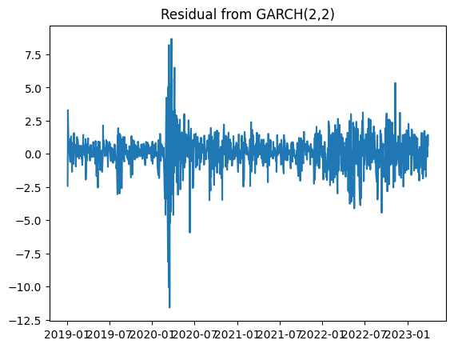

```python
residual_garch22 = garch22.resid
plt.plot(residual_garch22)
plt.title("Residual from GARCH(2,2)")
plt.show()
```

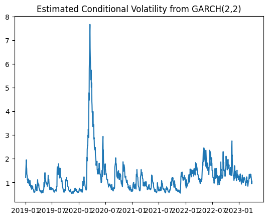

```python
volatility_garch22 = garch22.conditional_volatility
plt.plot(volatility_garch22)
plt.title("Estimated Conditional Volatility from GARCH(2,2)")
plt.show()
```

### **1. Is `garch22.resid` Simply the Actual Returns?**

**No,** but it's very close.

Since we set `mean="Zero"`, the model assumes the **expected return is 0**, meaning the residuals **are just the raw returns with no trend removed**:  
[ \text{Residuals} = \text{Actual Returns} - \text{Predicted Mean} ] Since the mean is **0**, we get: [ \text{Residuals} = \text{Actual Returns} ]

So in this case, **the residuals look like the actual returns**, but they still serve an important purpose in volatility modeling.

### **2. Then, What’s the Point of Using GARCH(2,2)?**

The key purpose of **GARCH(2,2)** is **not to predict the returns themselves** but to model and forecast **volatility** (conditional variance).

Here's what GARCH(2,2) does:

- It assumes **returns have periods of high and low volatility** (volatility clustering).
- It estimates **how much today's volatility depends on past volatility and past shocks**.
- Instead of focusing on predicting **returns**, it predicts **how volatile returns will be in the future**.

The model gives us **two key outputs**:

1. **`garch22.resid` (Residuals)**:
   - These are the **unexpected shocks** in returns.
   - In this case, since we set `mean="Zero"`, they look like actual returns.
2. **`garch22.conditional_volatility`**:
   - This is the estimated **volatility (σₜ)** of returns at each time step.
   - This is the real output of the model! It tells us **when the market is in a high-volatility or low-volatility state**.

### **3. What You Actually Need to Use from the Model**

To understand the usefulness of **GARCH(2,2)**, check its **conditional volatility**:

```
volatility_garch22 = garch22.conditional_volatility
plt.plot(volatility_garch22)
plt.title("Estimated Conditional Volatility from GARCH(2,2)")
plt.show()
```

This will show the **volatility forecast**, which is the main reason we use GARCH!

### **Final Takeaway**

- `garch22.resid` = Shocks (unexpected changes), which in this case resemble actual returns.
- `garch22.conditional_volatility` = The key **forecasted volatility**, which is what GARCH is really about.
- GARCH is not for predicting **returns**, but for predicting **how volatile returns will be** in the future.

# 3. Perform McLeod-Li Test and Jarque-Bera Test (no need to do them four times!).

# Make comments based on your observation.

### **Model Evaluation Summary**

#### **McLeod-Li Test (ARCH Effects)**

The McLeod-Li Test checks for ARCH effects in residuals. For all four models (ARCH(1), ARCH(2), GARCH(1,1), GARCH(2,2)), the p-values are extremely small (≈3.27e-52), rejecting the null hypothesis and indicating the presence of ARCH effects.

#### **Jarque-Bera Test (Normality of Residuals)**

The Jarque-Bera Test assesses residual normality. All models have very small p-values, rejecting the null hypothesis and confirming non-normal residuals.

#### **Overall Model Performance**

- The **ARCH(1) model** had the lowest RMSE as discovered above, indicating slightly better predictive performance.
- However, differences across models were minor, and none effectively captured volatility dynamics or residual normality.
- The **McLeod-Li Test** confirmed unmodeled volatility, and the **Jarque-Bera Test** showed residuals were non-normal, violating model assumptions.

### **Conclusion**

Despite ARCH(1) showing marginally better accuracy, all models are inadequate for modeling SPY ETF returns, failing to fully capture volatility and distributional characteristics.

```python
# Function to perform McLeod-Li Test
def mcleod_li_test(residuals):
    result = acorr_ljungbox(residuals**2, lags=[1], return_df=True)
    if isinstance(result, pd.DataFrame):
        test_statistic = result['lb_stat'].iloc[0]
        p_value = result['lb_pvalue'].iloc[0]
    else:
        test_statistic, p_value = result
    return test_statistic, p_value

# Function to perform Jarque-Bera Test
def jarque_bera_test(residuals):
    jb_test_statistic, jb_p_value = jarque_bera(residuals)
    return jb_test_statistic, jb_p_value
```

```python
# Perform McLeod-Li Test
ml_arch1 = mcleod_li_test(residuals_arch1)
ml_arch2 = mcleod_li_test(residuals_arch2)
ml_garch11 = mcleod_li_test(residuals_garch11)
ml_garch22 = mcleod_li_test(residuals_garch22)

# Perform Jarque-Bera Test
jb_arch1 = jarque_bera_test(std_resid_arch1)
jb_arch2 = jarque_bera_test(std_resid_arch2)
jb_garch11 = jarque_bera_test(std_resid_garch11)
jb_garch22 = jarque_bera_test(std_resid_garch22)
```

```python
print(f"McLeod-Li Test for ARCH(1): Test Statistic = {ml_arch1[0]}, p-value = {ml_arch1[1]}")
print(f"McLeod-Li Test for ARCH(2): Test Statistic = {ml_arch2[0]}, p-value = {ml_arch2[1]}")
print(f"McLeod-Li Test for GARCH(1,1): Test Statistic = {ml_garch11[0]}, p-value = {ml_garch11[1]}")
print(f"McLeod-Li Test for GARCH(2,2): Test Statistic = {ml_garch22[0]}, p-value = {ml_garch22[1]}")
```

```
McLeod-Li Test for ARCH(1): Test Statistic = 231.19425741083893, p-value = 3.2726369451739124e-52
McLeod-Li Test for ARCH(2): Test Statistic = 231.19425741083893, p-value = 3.2726369451739124e-52
McLeod-Li Test for GARCH(1,1): Test Statistic = 231.19425741083893, p-value = 3.2726369451739124e-52
McLeod-Li Test for GARCH(2,2): Test Statistic = 231.19425741083893, p-value = 3.2726369451739124e-52
```

```python
print(f"Jarque-Bera Test for ARCH(1): Test Statistic = {jb_arch1[0]}, p-value = {jb_arch1[1]}")
print(f"Jarque-Bera Test for ARCH(2): Test Statistic = {jb_arch2[0]}, p-value = {jb_arch2[1]}")
print(f"Jarque-Bera Test for GARCH(1,1): Test Statistic = {jb_garch11[0]}, p-value = {jb_garch11[1]}")
print(f"Jarque-Bera Test for GARCH(2,2): Test Statistic = {jb_garch22[0]}, p-value = {jb_garch22[1]}")
```

```
Jarque-Bera Test for ARCH(1): Test Statistic = 537.8471488868397, p-value = 1.6142677315989747e-117
Jarque-Bera Test for ARCH(2): Test Statistic = 285.096622410603, p-value = 1.2361040771808444e-62
Jarque-Bera Test for GARCH(1,1): Test Statistic = 188.4386707857609, p-value = 1.2052095109955479e-41
Jarque-Bera Test for GARCH(2,2): Test Statistic = 186.01647728040743, p-value = 4.046086722110928e-41
```

### **1. Understanding `garch22.resid` (Residuals in GARCH)**

- The **residuals (`garch22.resid`) are not exactly "shocks" in the GARCH sense** but rather **the difference between actual returns and the model's predicted mean**.
- Since we set `mean="Zero"`, the **predicted mean is always 0**, so the residuals are just: [ \text{Residuals} = \text{Actual Returns} ]
  - This is why the residuals *resemble* actual returns.
  - However, GARCH doesn't just model the residuals—it models **how the variance of residuals changes over time**.

### **2. Why Shouldn't Residuals Still Contain ARCH Effects?**

- **Before fitting GARCH:** The raw returns (or residuals in a simpler model) **should** show strong **ARCH effects** (volatility clustering).
- **After fitting GARCH:** If the model is good, `garch22.resid` should behave like **white noise**—meaning **no more volatility clustering should remain**.

That’s why we perform the **McLeod-Li test** on `garch22.resid`.

- **If the test still finds ARCH effects**, it means the GARCH model **has not fully explained** the volatility pattern.
- **If no significant ARCH effects remain**, the model has successfully captured the volatility structure.

### **3. Why Doesn’t This Make the Model Useless?**

The true output of a **GARCH model is not the residuals (`resid`)—it’s the conditional volatility (`conditional_volatility`)**, which represents the estimated standard deviation at each time step.

**Key takeaway:**

- `garch22.resid` should become **white noise** if the model is good.
- `garch22.conditional_volatility` is the real **volatility forecast** we care about.
- A good model will make the **McLeod-Li test on `resid` non-significant**, meaning **no remaining ARCH effects**.
- `garch22.resid` should become **white noise** if the model is good because **GARCH models volatility, not returns**.
- GARCH **removes volatility clustering**, meaning the residuals should no longer show patterns of changing variance.
- While `garch22.resid` may still have some randomness, its **variance should no longer be autocorrelated**—which is why it should resemble white noise.

### **Final Answer: What Should You Expect from McLeod-Li Test on `garch22.resid`?**

- **If `garch22` is a good model** → **No significant ARCH effects** in residuals (p-value > 0.05).
- **If `garch22` is not sufficient** → **Significant ARCH effects still present** (p-value < 0.05), meaning you might need a more complex model like GARCH(3,2) or an asymmetric model like **EGARCH**.

### **Summary**

1. **`garch22.resid` should resemble raw returns but should no longer show volatility clustering.**
2. **The true output of GARCH is `garch22.conditional_volatility` (not `resid`).**
3. **A good model removes ARCH effects from residuals (confirmed by McLeod-Li test).**
4. **If McLeod-Li test finds ARCH effects, GARCH(2,2) is not enough, and a more complex model is needed.**

A good GARCH model removes this changing variance, leaving a process where:

The values (residuals) still look similar to returns.

But their variance no longer follows a predictable pattern.

This means the squared residuals should not be autocorrelated anymore.

# 4. Make a One-step ahead rolling forecast on testing sample based on your final model.

# Make comments based on your observation.

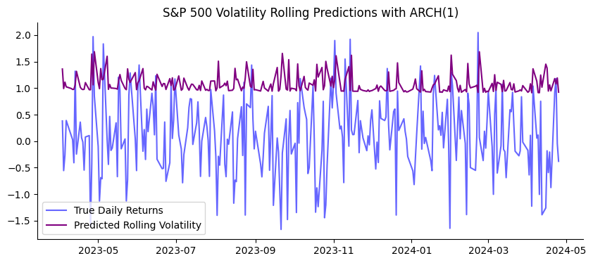

```python
# Compute log returns (excluding the first NaN value)
diff_ts = df['Return'].iloc[1:]

# Initialize rolling predictions list
rolling_preds = []

# One-step ahead rolling forecast
for i in range(len(test)):
    # Update training data to include actual observed returns up to time t
    train = diff_ts[:-(len(test) - i)]

    # Fit ARCH(1) model
    model = arch_model(train, vol='ARCH', p=1, rescale=False)
    model_fit = model.fit(disp='off')

    # Forecast one step ahead
    pred = model_fit.forecast(horizon=1, reindex=True)

    # Store the predicted volatility (square root of variance)
    rolling_preds.append(np.sqrt(pred.variance.values[-1, :][0]))

# Convert rolling predictions to a pandas Series
rolling_preds = pd.Series(rolling_preds, index=test.index)

# Plot True Daily Returns and Predicted Rolling Volatility
fig, ax = plt.subplots(figsize=(10, 4))
ax.spines[['top', 'right']].set_visible(False)

# Plot True Daily Returns
ax.plot(diff_ts[-len(test):], color='blue', alpha=0.6, label='True Daily Returns')

# Plot Predicted Rolling Volatility
ax.plot(test.index, rolling_preds, color='purple', label='Predicted Rolling Volatility')

# Title and legend
ax.set_title("S&P 500 Volatility Rolling Predictions with ARCH(1)")
ax.legend()

# Show the plot
plt.show()
```

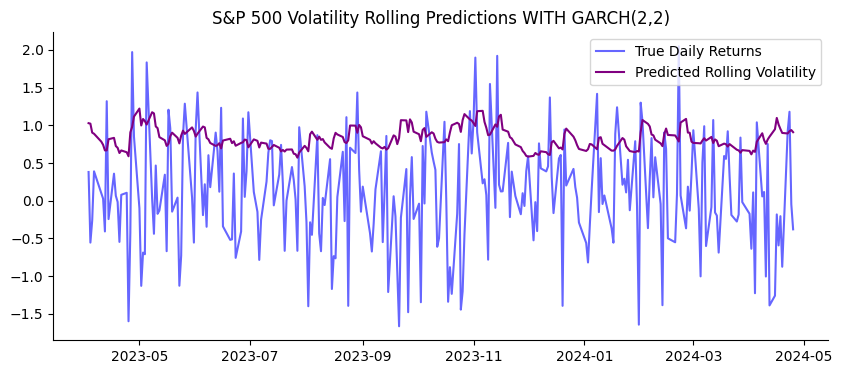

```python
# Compute log returns (excluding the first NaN value)
diff_ts = df['Return'].iloc[1:]

# Initialize rolling predictions list
rolling_preds_GARCH = []

# One-step ahead rolling forecast
for i in range(len(test)):
    # Update training data to include actual observed returns up to time t
    train = diff_ts[:-(len(test) - i)]

    # Fit an ARCH model (adjust parameters as needed)
    model = arch_model(train, p=2, q=2, rescale=False)
    model_fit = model.fit(disp='off')

    # Forecast one step ahead
    pred = model_fit.forecast(horizon=1, reindex=True)

    # Store the predicted volatility (square root of variance)
    rolling_preds_GARCH.append(np.sqrt(pred.variance.values[-1, :][0]))

# Convert rolling predictions to a pandas Series
rolling_preds_GARCH = pd.Series(rolling_preds_GARCH, index=test.index)

# Plot True Daily Returns and Predicted Rolling Volatility
fig, ax = plt.subplots(figsize=(10, 4))
ax.spines[['top', 'right']].set_visible(False)

# Plot True Daily Returns
ax.plot(diff_ts[-len(test):], color='blue', alpha=0.6, label='True Daily Returns')

# Plot Predicted Rolling Volatility
ax.plot(test.index, rolling_preds_GARCH, color='purple', label='Predicted Rolling Volatility')

# Title and legend
ax.set_title("S&P 500 Volatility Rolling Predictions WITH GARCH(2,2)")
ax.legend()

# Show the plot
plt.show()
```

### **Observation on S&P 500 Volatility Rolling Predictions with GARCH(2,2):**

1. **True Daily Returns (Blue Line)**: Remains highly volatile, showing large fluctuations.
2. **Predicted Rolling Volatility (Purple Line)**: Smoother than the ARCH(1) model, better capturing the volatility clustering over time.
3. **Improvement**: GARCH(2,2) adapts to changes in volatility more effectively than ARCH(1), reflecting periods of high and low market turbulence.
4. **Remaining Issue**: Still lags behind sudden volatility spikes, though it provides a more dynamic response compared to ARCH(1).
5. **Implication**: GARCH(2,2) is a better fit for modeling SPY volatility, but further refinement (e.g., incorporating asymmetric effects with GJR-GARCH) could improve capturing extreme movements.